# Applied Predictive Modeling–Chapter 3 Data Pre-processing

Author: Rick Dean

Article date: 2021-02-01

Abstract

The following notes/scripts/plots are inspired by Chapter 3 Data Pre-processing of [Applied Predictive Modeling](http://appliedpredictivemodeling.com/) by Max Kuhn and Kjell Johnson.

Note: Look in the “chapters” directory of the AppliedPredictiveModeling package for the R scripts used in the book.

```r
library(data.table)
library(ggplot2)
library(ggrepel)
library(caret)
library(AppliedPredictiveModeling)
library(e1071)
library(grid)
library(gtable)
library(RregressPkg)
library(RplotterPkg)
```

## 3.1 Case Study: Cell Segmentation in High-Content Screening

Task: Prepare the training set.

1. Access the data and retain the original training set:

```r
data(segmentationOriginal, package = "AppliedPredictiveModeling")
seg_orig_dt <- data.table::setDT(segmentationOriginal)
seg_data_dt <- seg_orig_dt[Case == "Train"]
```

2. Save the *Case*, *Class*, and *Cell* predictors in separate vectors:

```r
case_dt <- seg_data_dt[, .(Case)]
class_dt <- seg_data_dt[, .(Class)]
cell_dt <- seg_data_dt[, .(Cell)]
```

3. Remove the above 3 predictors from *seg_data_dt*:

```r
seg_data_dt <- seg_data_dt[, !c("Case", "Class", "Cell")]
```

4. Remove predictors that have “status” in their names:

```r
status_col_names <- base::grep("Status", colnames(seg_data_dt), value = T)
seg_data_dt <- seg_data_dt[, !..status_col_names]
```

## 3.2 Data Transformations for Individual Predictors

The column “VarIntenCh3” measures the standard deviation of the intensity of the pixels in the actin filaments

Task: Review the skewness of “VarIntenCh3”.

> A general rule of thumb to consider is that skewed data whose ratio of the highest value to the lowest value is greater than 20 have significant skewness.
1. VarIntenCh3 ratio max/min:

```r
max(seg_data_dt$VarIntenCh3)/min(seg_data_dt$VarIntenCh3)
```

```
## [1] 870.8872
```

2. VarIntenCh3 skewness:

```r
e1071::skewness(seg_data_dt$VarIntenCh3)
```

```
## [1] 2.391624
```

Task: Use `caret::preProcess()` to transform for skewness.

1. Run `caret::preProcess()` using “BoxCox” for *method*:

```r
pre_process_lst <- caret::preProcess(seg_data_dt, method = "BoxCox")
```

The class for *pre_process_lst* is “preProcess” which tells `stats::predict()` to return a transformed data frame.

2. Apply *pre_process_lst* to transform *seg_data_dt* using `stats::predict()`:

```r
seg_data_dt <- data.table::setDT(stats::predict(pre_process_lst, seg_data_dt))
```

3. The $\lambda$ used in the transformation:

```r
pre_process_lst$bc$VarIntenCh3$lambda
```

```
## [1] 0.1
```

4. Plot the histogram of both the original and transformed data of predictor variable *VarIntenCh3*:

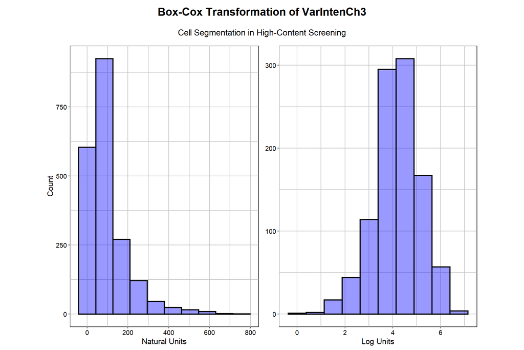

```r
plot_1 <- RplotterPkg::create_histogram_plot(
  df = seg_orig_dt[, .(VarIntenCh3)],
  aes_x = "VarIntenCh3",
  rot_y_tic_label = TRUE,
  bins = 10,
  bar_fill = "blue",
  x_title = "Natural Units"
)

plot_2 <- RplotterPkg::create_histogram_plot(
  df = seg_data_dt,
  aes_x = "VarIntenCh3",
  rot_y_tic_label = TRUE,
  bins = 10,
  bar_fill = "blue",
  x_title = "Log Units",
  do_y_title = FALSE
)

layout <- list(
  plots = list(plot_1, plot_2),
  rows = c(1,1),
  cols = c(1,2)
)

plot_3 <- RplotterPkg::multi_panel_grid(
  layout = layout,
  col_widths = c(5,5),
  row_heights = 7,
  title = "Box-Cox Transformation of VarIntenCh3",
  subtitle = "Cell Segmentation in High-Content Screening",
)
```

5. VarIntenCh3 skewness after Box-Cox transformation:

```r
e1071::skewness(seg_data_dt$VarIntenCh3)
```

```
## [1] -0.4037864
```

## 3.3 Data Transformations for Multiple Predictors

Task: Use Principal Components Analysis (PCA) to find linear combinations of predictors.

> PCA seeks to find linear combinations of predictors, known as principal components (PC’s) which capture the most possible variance. The first PC is defined as the linear combination of the predictors that captures the most variability of all the possible linear combinations.
1. Consider two highly correlated predictors from *seg_data_dt* where PCA could be used to select one that explains the most variance:
   1. average pixel intensity of channel 1 (AvgIntenCh1)
   2. entropy of intensity of channel 1(EntropyIntenCh1)
2. Estimate the linear model between the two predictors:

```r
fit_lm <- stats::lm(AvgIntenCh1 ~ EntropyIntenCh1, data = seg_data_dt)
```

```r
summary(fit_lm)$r.squared
```

```
## [1] 0.8678278
```

4. Show a scatter plot of the predictors with the *Class* predictor as an aes fill:

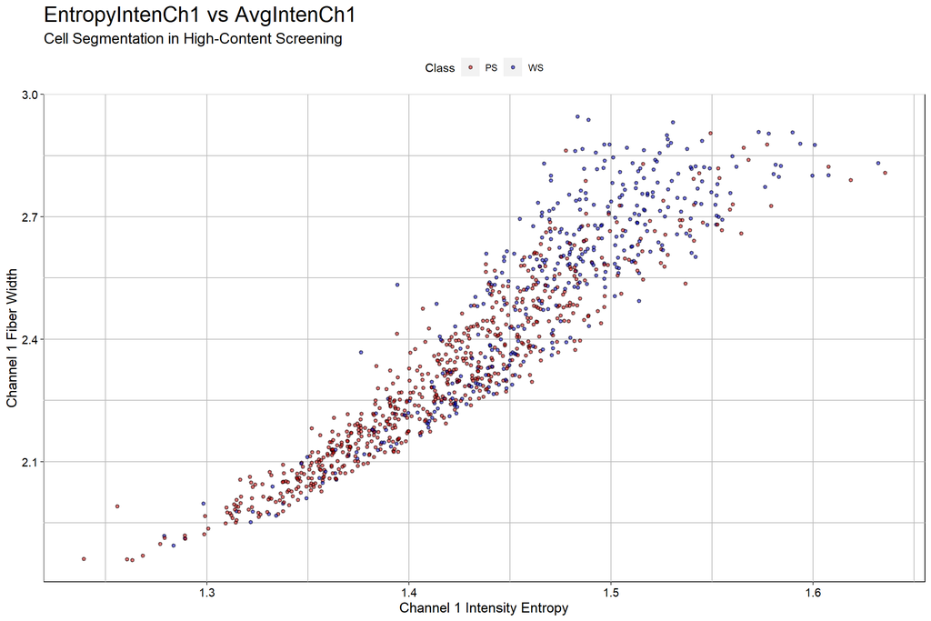

```r
df <- cbind(seg_data_dt, class_dt)
RplotterPkg::create_scatter_plot(
  df = df,
  aes_x = "EntropyIntenCh1",
  aes_y = "AvgIntenCh1",
  aes_fill = "Class",
  title = "EntropyIntenCh1 vs AvgIntenCh1",
  subtitle = "Cell Segmentation in High-Content Screening",
  x_title = "Channel 1 Intensity Entropy",
  y_title = "Channel 1 Fiber Width",
  rot_y_tic_label = TRUE,
  pts_line_alpha = 0.5,
  palette_colors = c("red","blue")
)
```

5. Compute the PCA involving the two predictors:

```r
pca <- stats::prcomp(formula = ~ AvgIntenCh1 + EntropyIntenCh1, data = seg_data_dt, scale. = TRUE)
```

6. Show a scatter plot to the two principal components:

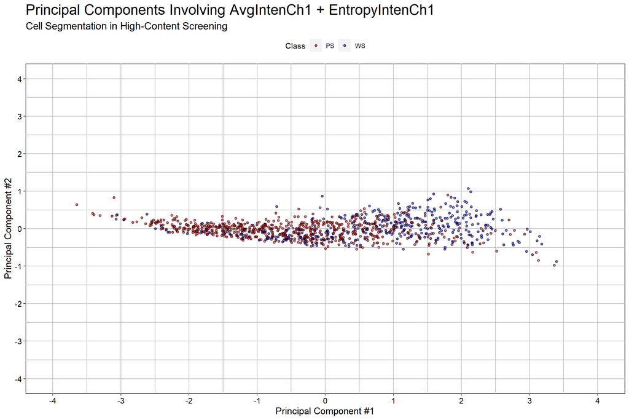

```r
dt <- data.table::as.data.table(pca$x)
dt[, Class := class_dt$Class]

RplotterPkg::create_scatter_plot(
  df = dt,
  aes_x = "PC1",
  aes_y = "PC2",
  aes_fill = "Class",
  title = "Principal Components Involving AvgIntenCh1 + EntropyIntenCh1",
  subtitle = "Cell Segmentation in High-Content Screening",
  x_title = "Principal Component #1",
  y_title = "Principal Component #2",
  rot_y_tic_label = TRUE,
  pts_line_alpha = 0.5,
  x_limits = c(-4,4),
  x_major_breaks = seq(-4,4,1),
  y_limits = c(-4,4),
  y_major_breaks = seq(-4,4,1),
  palette_colors = c("red","blue")
)
```

> The first PC summarizes 97% of the original variability, while the second summarizes 3%. Hence it is reasonable to use only the first PC for modeling since it accounts for the majority of the information in the data.

Task: Plot the pca using `RregressPkg::plot_pca()`

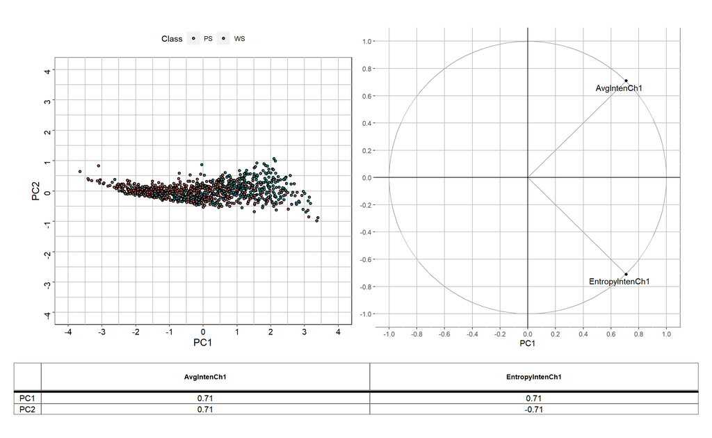

```r
df <- cbind(seg_data_dt, class_dt)
pca_plot <- RregressPkg::plot_pca(
  df = df,
  center = TRUE,
  scale. = TRUE,
  measures = c("AvgIntenCh1", "EntropyIntenCh1"),
  aes_fill = "Class",
  x_limits = c(-4,4),
  x_major_breaks = seq(-4,4,1),
  y_limits = c(-4,4),
  y_major_breaks = seq(-4,4,1),
  figure_width = 12
)
```

Task: Apply principal components to the entire set of segmentation predictors.

1. Remove those predictors that have only a single value:

```r
length_fun <- function(xx = NULL){
  if(length(unique(xx)) != 1){
    return(xx)
  }else{
    return(NULL)
  }
}
seg_data_dt[,colnames(seg_data_dt) := lapply(seg_data_dt, length_fun)]
```

2. Create scatterplot objects of PC1 vs PC2, PC1 vs PC3 and PC2 vs PC3 using RregressPkg::plot_pca():

```r
df <- cbind(seg_data_dt, class_dt)
measures <- colnames(seg_data_dt)

plot_1 <- RregressPkg::plot_pca(
  df = df,
  center = TRUE,
  scale. = TRUE,
  measures = measures,
  pca_pair = c("PC1", "PC2"),
  aes_fill = "Class",
  palette_colors = c("red", "blue"),
  figure_width = 4,
  display_plot = FALSE
)

plot_2 <- RregressPkg::plot_pca(
  df = df,
  center = TRUE,
  scale. = TRUE,
  measures = measures,
  pca_pair = c("PC1", "PC3"),
  aes_fill = "Class",
  palette_colors = c("red", "blue"),
  figure_width = 4,
  display_plot = FALSE
)

plot_3 <- RregressPkg::plot_pca(
  df = df,
  center = TRUE,
  scale. = TRUE,
  measures = measures,
  pca_pair = c("PC2", "PC3"),
  aes_fill = "Class",
  palette_colors = c("red", "blue"),
  figure_width = 4,
  display_plot = FALSE
)
```

3. Set a layout for the 3 plots and display:

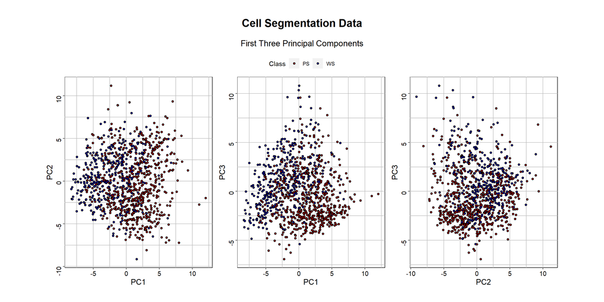

```r
layout <- list(
  plots = list(plot_1$samp_plot, plot_2$samp_plot, plot_3$samp_plot),
  rows = c(1, 1, 1),
  cols = c(1, 2, 3)
)
col_widths <- c(4, 4, 4)
row_heights <- c(5)

pca_figure <- RplotterPkg::multi_panel_grid(
  layout = layout,
  col_widths = col_widths,
  row_heights = row_heights,
  title = "Cell Segmentation Data",
  subtitle = "First Three Principal Components",
  do_legend = TRUE
)
```

## 3.4 Dealing with Missing Values

(no scripts)

## 3.5 Removing Predictors

Task: Use the algorithm outlined on page 47 to identify segmentation predictors with low colinearity.

1. Compute the correlation matrix for the *seg_data_dt*:

```r
seg_cor <- stats::cor(seg_data_dt)
```

2. Call `RregressPkg::low_predictor_collinearity()`:

```r
results_lst <- RregressPkg::low_predictor_collinearity(seg_cor)
```

The algorithm suggest of the 58 variables, 34 high correlations (to possible remove) and 24 low predictor correlations:

```r
results_lst$predictors
```

```
##  [1] "AngleCh1"             "DiffIntenDensityCh4"  "EntropyIntenCh3"
##  [4] "FiberAlign2Ch3"       "FiberAlign2Ch4"       "FiberLengthCh1"
##  [7] "FiberWidthCh1"        "IntenCoocContrastCh3" "IntenCoocMaxCh4"
## [10] "NeighborMinDistCh1"   "NeighborVarDistCh1"   "ShapeBFRCh1"
## [13] "ShapeLWRCh1"          "SkewIntenCh1"         "SkewIntenCh3"
## [16] "SkewIntenCh4"         "SpotFiberCountCh3"    "SpotFiberCountCh4"
## [19] "TotalIntenCh1"        "TotalIntenCh2"        "VarIntenCh3"
## [22] "WidthCh1"             "XCentroid"            "YCentroid"
```

Task: Use `caret::findCorrelation()` to identify columns to remove.

```r
high_cor_indexes <- caret::findCorrelation(seg_cor, 0.75)
high_cor_names <- colnames(seg_cor)[high_cor_indexes]
low_cor_names <- colnames(seg_cor)[-high_cor_indexes]
```

Results for `caret::findCorrelation()`–

Number with high correlations: 34

Number with low correlations: 24

## 3.8 Creating Dummy Variables

Task: Create dummy variables from the *cars* data set in the caret package.

1. Show the data set:

```r
data("cars", package = "caret")
cars_dt <- data.table::setDT(cars)
```

2. Define a “Type” factor:

```r
cars_dt[, Type := data.table::fcase(convertible == 1,"convertible",
                        coupe == 1,"coupe",
                        hatchback == 1,"hatchback",
                        sedan == 1,"sedan",
                        wagon == 1,"wagon")]
cars_dt[, Type := factor(Type)]
cars_dt <- cars_dt[,.(Price, Mileage, Type)]
head(cars_dt)
```

```
##       Price Mileage        Type
## 1: 22661.05   20105       sedan
## 2: 21725.01   13457       coupe
## 3: 29142.71   31655 convertible
## 4: 30731.94   22479 convertible
## 5: 33358.77   17590 convertible
## 6: 30315.17   23635 convertible
```

3. Define a subset of *cars_dt*:

```r
cars_subset_dt <- cars_dt[sample(1:nrow(cars_dt), 40),]
```

4. Use `caret::dummyVars()` to model Price as a simple additive function of *Mileage* and *Type*:

```r
simple_mod <- caret::dummyVars(Price ~ Mileage + Type, data = cars_subset_dt, levelsOnly = TRUE)
simple_mod
```

```
## Dummy Variable Object
##
## Formula: Price ~ Mileage + Type
## 3 variables, 1 factors
## Factor variable names will be removed
## A less than full rank encoding is used
```

5. Use `stats::predict()` with the model to generate the dummy variables on *cars_dt*:

```r
cars_with_dummy_mt <- stats::predict(simple_mod, cars_dt)
head(cars_with_dummy_mt)
```

```
##   Mileage convertible coupe hatchback sedan wagon
## 1   20105           0     0         0     1     0
## 2   13457           0     1         0     0     0
## 3   31655           1     0         0     0     0
## 4   22479           1     0         0     0     0
## 5   17590           1     0         0     0     0
## 6   23635           1     0         0     0     0
```

> The *Type* was expanded into five variables for five factor levels. The model is simple because it assumes that the effect of the mileage is the same for every type of car. To fit a more advanced model, we could assume that there is a **joint** effect of mileage and car type. This type of effect is referred to as an interaction. In the model formula , a colon between factors indicates that an interaction should be generated.

Task: Create an interaction effects model.

1. Define the interaction effects model:

```r
interact_mod <- caret::dummyVars(~ Mileage + Type + Mileage:Type, data = cars_subset_dt, levelsOnly = TRUE)
interact_mod
```

```
## Dummy Variable Object
##
## Formula: ~Mileage + Type + Mileage:Type
## 2 variables, 1 factors
## Factor variable names will be removed
## A less than full rank encoding is used
```

2. Generate the dummy variables using `stats::predict()` on *cars_dt*:

```r
cars_with_dummy_inter_mt <- stats::predict(interact_mod, cars_dt)
head(cars_with_dummy_inter_mt)
```

```
##   Mileage convertible coupe hatchback sedan wagon Mileage:Typeconvertible
## 1   20105           0     0         0     1     0                       0
## 2   13457           0     1         0     0     0                       0
## 3   31655           1     0         0     0     0                   31655
## 4   22479           1     0         0     0     0                   22479
## 5   17590           1     0         0     0     0                   17590
## 6   23635           1     0         0     0     0                   23635
##   Mileage:Typecoupe Mileage:Typehatchback Mileage:Typesedan Mileage:Typewagon
## 1                 0                     0             20105                 0
## 2             13457                     0                 0                 0
## 3                 0                     0                 0                 0
## 4                 0                     0                 0                 0
## 5                 0                     0                 0                 0
## 6                 0                     0                 0                 0
```